# Alcohol Consumption

The dataset below was downloaded from Gapminder. It includes the recorded and/or estimated alcohol consumption per adult (age 15+) in litres pure alcohol by country from 1985 to 2008.

```r
alc <- read.csv('alcohol consumption.csv')

head(alc)
```

```
##                     X X1985 X1986 X1987 X1988 X1989 X1990 X1991 X1992
## 1         Afghanistan    NA    NA    NA    NA    NA    NA    NA    NA
## 2             Albania    NA    NA    NA    NA    NA    NA    NA    NA
## 3             Algeria    NA    NA    NA    NA    NA    NA    NA    NA
## 4             Andorra    NA    NA    NA    NA    NA    NA    NA    NA
## 5              Angola    NA    NA    NA    NA    NA    NA    NA    NA
## 6 Antigua and Barbuda    NA    NA    NA    NA    NA    NA    NA    NA
##   X1993 X1994 X1995 X1996 X1997 X1998 X1999 X2000 X2001 X2002 X2003 X2004
## 1    NA    NA    NA    NA    NA    NA    NA    NA    NA    NA    NA    NA
## 2    NA    NA    NA    NA    NA    NA    NA    NA    NA    NA    NA    NA
## 3    NA    NA    NA    NA    NA    NA    NA    NA    NA    NA    NA    NA
## 4    NA    NA    NA    NA    NA    NA    NA    NA    NA    NA    NA    NA
## 5    NA    NA    NA    NA    NA    NA    NA    NA    NA    NA    NA    NA
## 6    NA    NA    NA    NA    NA    NA    NA    NA    NA    NA    NA    NA
##   X2005 X2006 X2007 X2008
## 1  0.02    NA    NA  0.03
## 2  6.68    NA    NA  7.29
## 3  0.96    NA    NA  0.69
## 4 15.48    NA    NA 10.17
## 5  5.40    NA    NA  5.57
## 6  7.22    NA    NA  8.17
```

```r
# adjust columns and remove N/A values from alcohol column
alc_df <- gather(alc, "year", "alcohol", -1) %>% subset(!is.na(alcohol))

# change country column name
colnames(alc_df)[1] <- 'country'

# remove 'X' from years column and convert to numeric
alc_df$year <- substring(alc_df$year, 2, 5)
alc_df <- transform(alc_df, year = as.numeric(year))

head(alc_df)
```

```
##     country year alcohol
## 139  Russia 1985   13.31
## 328  Russia 1986   10.77
## 517  Russia 1987   10.96
## 706  Russia 1988   11.57
## 895  Russia 1989   12.04
## 980   Chile 1990    9.43
```

### Data Exploration

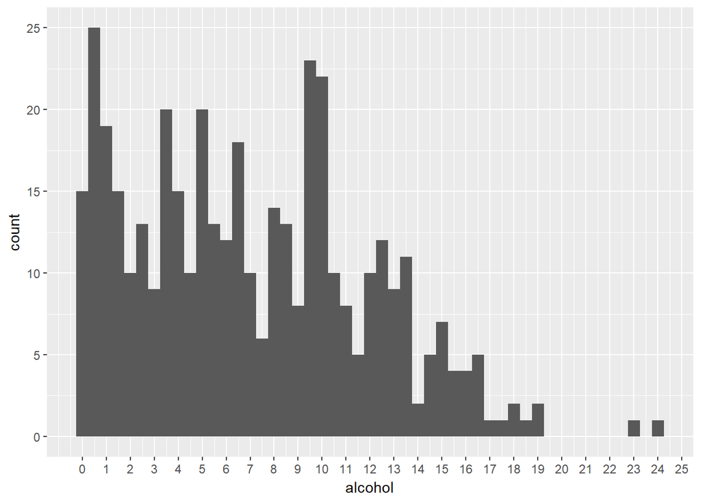

```r
library(ggplot2)
qplot(x = alcohol, data = alc_df, binwidth = 0.5) +
  scale_x_continuous(breaks = seq(0,25,1))
```

The alcohol consumption data does not have a simple distribution. It appears that most of the records indicate an alcohol consumption of 10 litres or less per adult. The distribution could be loosely described as right-skewed, but there are clear peaks at both 1 litre and 10 litres, as well as some peaks and valleys in between.

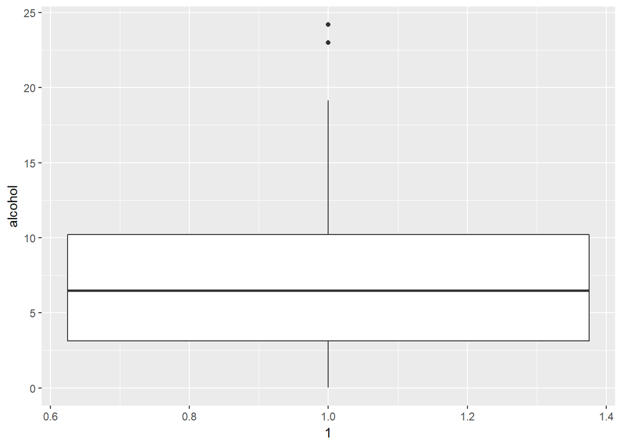

```r
qplot(x = 1, y = alcohol, data = alc_df, geom = 'boxplot')
```

A boxplot of all of the alcohol consumption data shows a median around 6.5-7 litres per adult, with the middle 50% of data falling between 3 litres and 10 litres. There are also a couple outliers greater than 22.5 litres per adult.

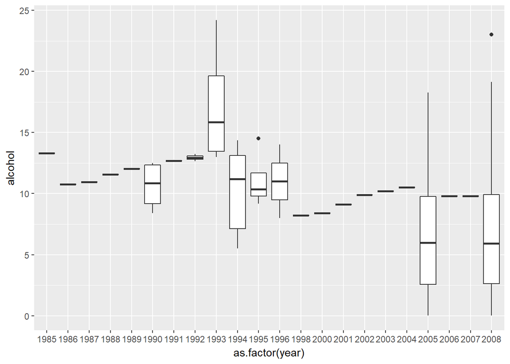

```r
qplot(x = as.factor(year), y = alcohol, data = alc_df, geom = 'boxplot')
```

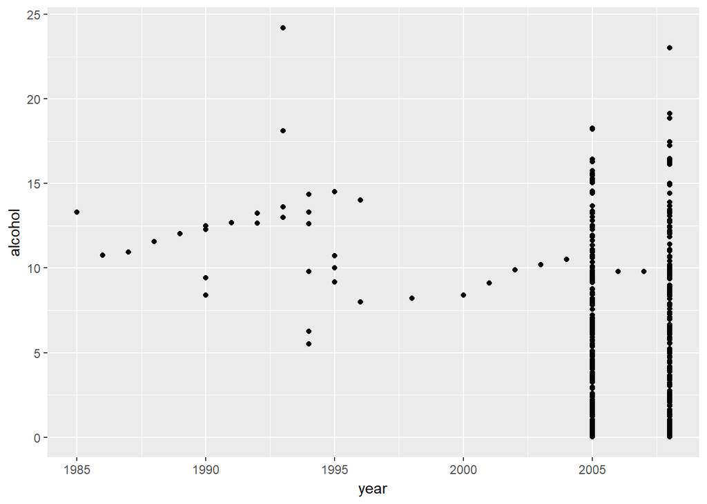

```r
qplot(x = year, y = alcohol, data = alc_df)
```

The boxplot and scatterplot of alcohol consumption by year shows a large variation in alcohol consumption over the years. It is also clear that most of the data is for 2005 and 2008, as all the other years have less than 10 data points. This lack of data across the years may limit what types of information we can pull from this dataset.

```r
table_year <- table(alc_df$year)

# create subset for years with at least 4 data values
subset_alc <- alc_df[alc_df$year %in% names(table_year[table_year >= 4]), ]

by(subset_alc$alcohol, subset_alc$year, summary)
```

```
## subset_alc$year: 1990
##    Min. 1st Qu.  Median    Mean 3rd Qu.    Max.
##   8.400   9.172  10.860  10.658  12.345  12.510
## --------------------------------------------------------
## subset_alc$year: 1993
##    Min. 1st Qu.  Median    Mean 3rd Qu.    Max.
##   13.00   13.45   15.85   17.22   19.62   24.19
## --------------------------------------------------------
## subset_alc$year: 1994
##    Min. 1st Qu.  Median    Mean 3rd Qu.    Max.
##   5.520   7.143  11.205  10.308  13.130  14.360
## --------------------------------------------------------
## subset_alc$year: 1995
##    Min. 1st Qu.  Median    Mean 3rd Qu.    Max.
##   9.190   9.797  10.370  11.113  11.685  14.520
## --------------------------------------------------------
## subset_alc$year: 2005
##    Min. 1st Qu.  Median    Mean 3rd Qu.    Max.
##   0.020   2.583   5.990   6.541   9.777  18.280
## --------------------------------------------------------
## subset_alc$year: 2008
##    Min. 1st Qu.  Median    Mean 3rd Qu.    Max.
##   0.030   2.625   5.920   6.689   9.925  23.010
```

By help of a table of the data, we can see that many of the years only have 1-2 data points. With such little data we cannot be confident at all about the data for these years. To attempt to deal with this issue, we have subsetted the data and only included years with at least 4 data points. It’s important to note that the subset data is still dominated by values from 2005 and 2008.

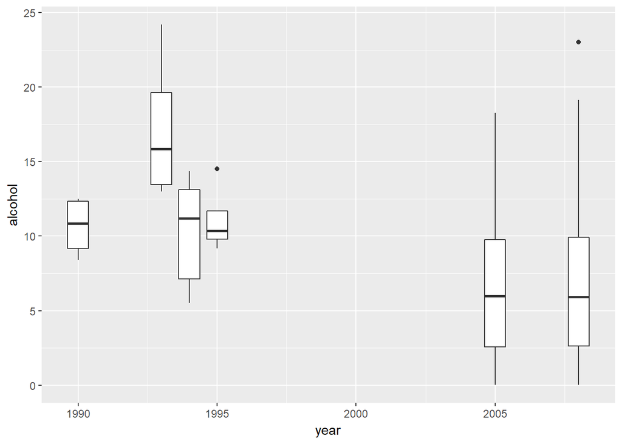

```r
ggplot(aes(group = year, x = year, y = alcohol), data = subset_alc) +
  geom_boxplot()
```

The boxplot for the years with at least 4 data points still shows a lot of variation. There isn’t a simple trend that can be detected in this plot. Below we’ll see if scatterplots can help make sense of the alcohol consumption by year.

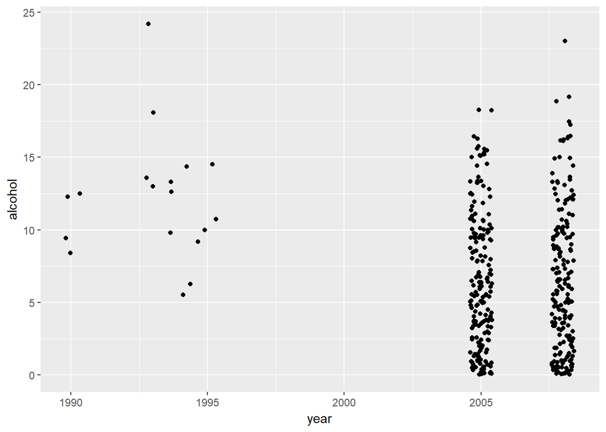

```r
ggplot(aes(x = year, y = alcohol), data = subset_alc) +
  geom_jitter()
```

It’s clear here that most of our data is in the years 2005 and 2008, but the alcohol consumption for all of the years seems to vary quite a bit.

```r
subset_alcByYear <- subset_alc %>% group_by(year) %>%
  summarise(alcohol_mean = mean(alcohol),
            alcohol_median = median(alcohol),
            n = n())
```

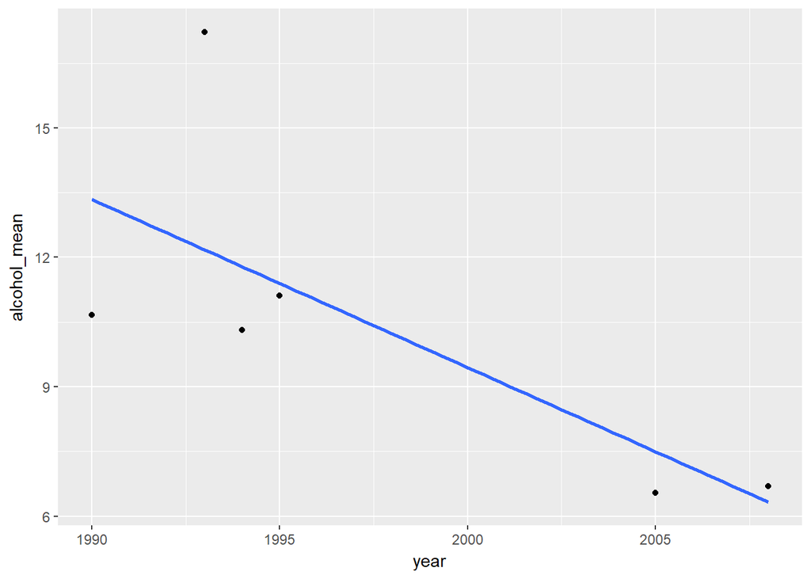

```r
ggplot(aes(x = year, y = alcohol_mean), data = subset_alcByYear) +
  geom_point() +
  geom_smooth(method = 'lm', se = FALSE)
```

Again, there is not a simple relationship that can be detected here but the plot shows a downward trend. Likely, there are not enough data points and too much variation between countries to be able to see a relationship between alcohol and year. Below we’ll try to investigate alcohol consumption over the years by individual countries.

```r
alcByCountry <- alc_df %>% group_by(country) %>% arrange(country)

count(alcByCountry) %>% subset(n > 10)
```

```
## # A tibble: 2 x 2
## # Groups:   country [2]
##   country     n
##   <fct>   <int>
## 1 Russia     12
## 2 Sweden     11
```

## Exploration by Country

Russia and Sweden are the only two countries that have more than 10 data points for alcohol consumption. We’ll look at these countries’ alcohol consumption over the years.

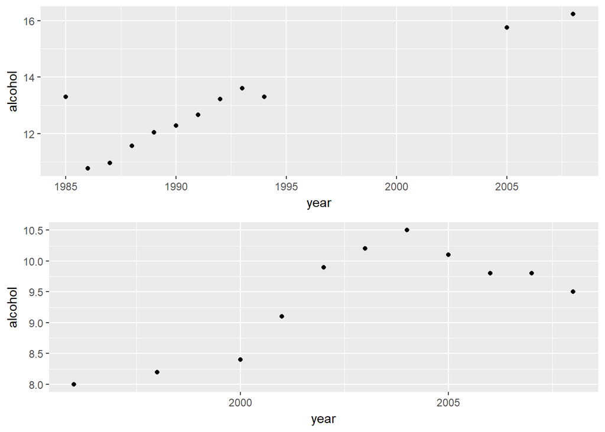

```r
Rus_df <- alc_df[alc_df$country == 'Russia', ]
Swe_df <- alc_df[alc_df$country == 'Sweden', ]

Rus <- ggplot(aes(x = year, y = alcohol), data = Rus_df) +
  geom_point()

Swe <- ggplot(aes(x = year, y = alcohol), data = Swe_df) +
  geom_point()

library(gridExtra)
grid.arrange(Rus, Swe, ncol = 1)
```

Based on these two countries, which admittedly is still a small sample, it appears that alcohol consumption has been generally increasing as time goes on. In recent years it seems that alcohol consumption has been on the decline in Sweden, but in Russia it increased from 2005 to 2008. Taking the variability due to the different countries out of the analysis, we get a clearer picture of the relationship between alcohol consumption over time.

```r
cor.test(Rus_df$year, Rus_df$alcohol)
```

```
##
##  Pearson's product-moment correlation
##
## data:  Rus_df$year and Rus_df$alcohol
## t = 6.6544, df = 10, p-value = 5.678e-05
## alternative hypothesis: true correlation is not equal to 0
## 95 percent confidence interval:
##  0.6836870 0.9728349
## sample estimates:
##       cor
## 0.9032006
```

```r
cor.test(Swe_df$year, Swe_df$alcohol)
```

```
##
##  Pearson's product-moment correlation
##
## data:  Swe_df$year and Swe_df$alcohol
## t = 3.5285, df = 9, p-value = 0.006429
## alternative hypothesis: true correlation is not equal to 0
## 95 percent confidence interval:
##  0.2983132 0.9346005
## sample estimates:
##      cor
## 0.761854
```

The r values further demonstrate the positive correlation between alcohol consumption and year in both Sweden and Russia.

Scatter plot of alcohol by year colored by country - 189 different countries so we will again subset to include only Sweden and Russia, with overall mean to compare

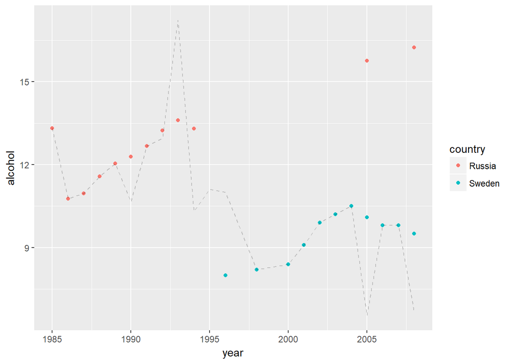

```r
alcByYear <- alc_df %>% group_by(year) %>%
  summarise(alcohol = mean(alcohol),
            alcohol_median = median(alcohol),
            n = n())

ggplot(aes(x = year, y = alcohol), data = alcByCountry) +
  geom_point(aes(color = country),
             data = subset(alcByCountry, country == 'Russia' | country == 'Sweden')) +
  geom_line(data = alcByYear, linetype = 2, alpha = 0.2)
```

We can see here that the alcohol consumption in Russia is higher than that in Sweden, and we can also see the positive trends in alcohol consumption over the years in these two countries. The overall mean line also shows the limitations we have with this dataset. The line jumps up and down often due to the lack of data for some years. It appears that Russia and Sweden may be the only data points for many years, greatly affecting the overall mean and limiting its usefulness.

As a further exploration, let us take a sample of 30 countries and see the trends in alcohol consumption that they show.

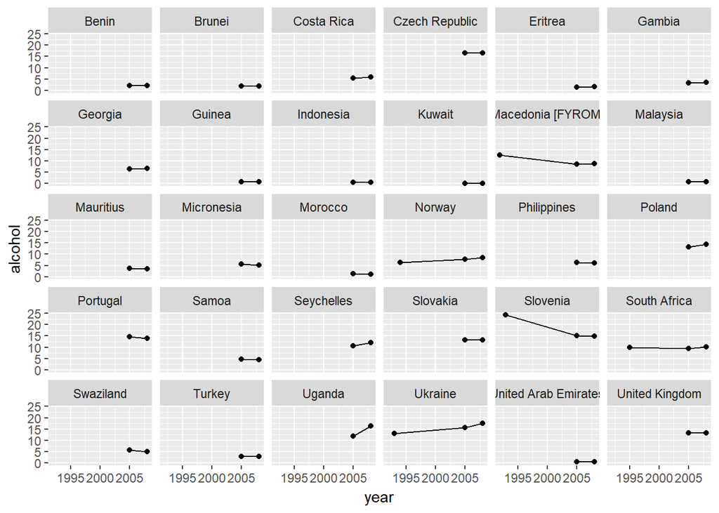

```r
# set seed
set.seed(23)
sample.ids <- sample(levels(alcByCountry$country), 30)

ggplot(aes(x = year, y = alcohol),
       data = subset(alcByCountry, country %in% sample.ids)) +
  facet_wrap( ~ country) +
  geom_line() +
  geom_point()
```

Based on these results it looks very inconclusive as to how alcohol is changing over the years in each country. It seems to be different in each country in this sample, which could be true for the population, but again the lack of data makes our conclusions very indeterminate.

## Further Analysis

Going forward, we could do a further analysis between the years 2005 and 2008 since this is where most of the data points came from. It would be interesting to explore whether alcohol consumption has generally increased or decreased from 2005 to 2008. In Russia it increased, but in Sweden it decreased. We could perform some data exploration prior to performing further statistical tests to get an idea of which direction alcohol consumption changed between 2005 to 2008.